# Powerlifting Dataset Analysis

### Introduction

Powerlifting is a sport that tests an athlete’s maximal strength in three main lifts:

- **Squat**
- **Bench Press**
- **Deadlift**

In this project, we explore **how different factors impact powerlifting performance**:

- **Age**: How lifters’ age correlates with their performance in different lifts.
- **Weight Class**: How lifters in different weight classes compare in terms of their lifting capabilities.
- **Equipment Type**: Whether using `Single-ply`, `Raw`, or `Wraps` affects a lifter’s performance.

Our goal is to **uncover key trends** that can be used by lifters and coaches to optimize training and performance. We use:

- **`dplyr`** for data cleaning and transformation.
- **`ggplot2`** for visualizing the results.

This report will present a **cohesive narrative** on what contributes to successful powerlifting outcomes.

### Packages Required

```r
# Load necessary libraries
library(ggplot2)
library(dplyr)
# Load your data
cleaned_data <- read.csv("C:/Users/12818/Pictures/Screenshots/z_stuff/New folder/Untitled Export/ipf_lifts.csv")

# Clean the data
cleaned_data <- cleaned_data %>%
  filter(!is.na(age) & !is.na(best3squat_kg) & !is.na(best3bench_kg) & !is.na(best3deadlift_kg)) %>%
  mutate(
    best3squat_kg = ifelse(best3squat_kg < 0, NA, best3squat_kg),
    best3bench_kg = ifelse(best3bench_kg < 0, NA, best3bench_kg),
    best3deadlift_kg = ifelse(best3deadlift_kg < 0, NA, best3deadlift_kg)
  )
```

### Data Source and Preparation

#### Data Source

The dataset used in this analysis was collected from the **International Powerlifting Federation (IPF)**. It consists of **24,018 entries** with information about powerlifting events, lifters’ attributes (such as age, sex, and bodyweight), and their best competition lifts in **squat**, **bench press**, and **deadlift**.

The data was gathered to understand trends in powerlifting performance across different demographics and equipment types. The dataset provides a valuable opportunity to identify factors that contribute to better lifts and performance optimization.

### Exploratory Data Analysis (EDA)

#### 1. Age Distribution of Lifters

To understand the typical age range of powerlifters, a histogram was created to show age distribution.

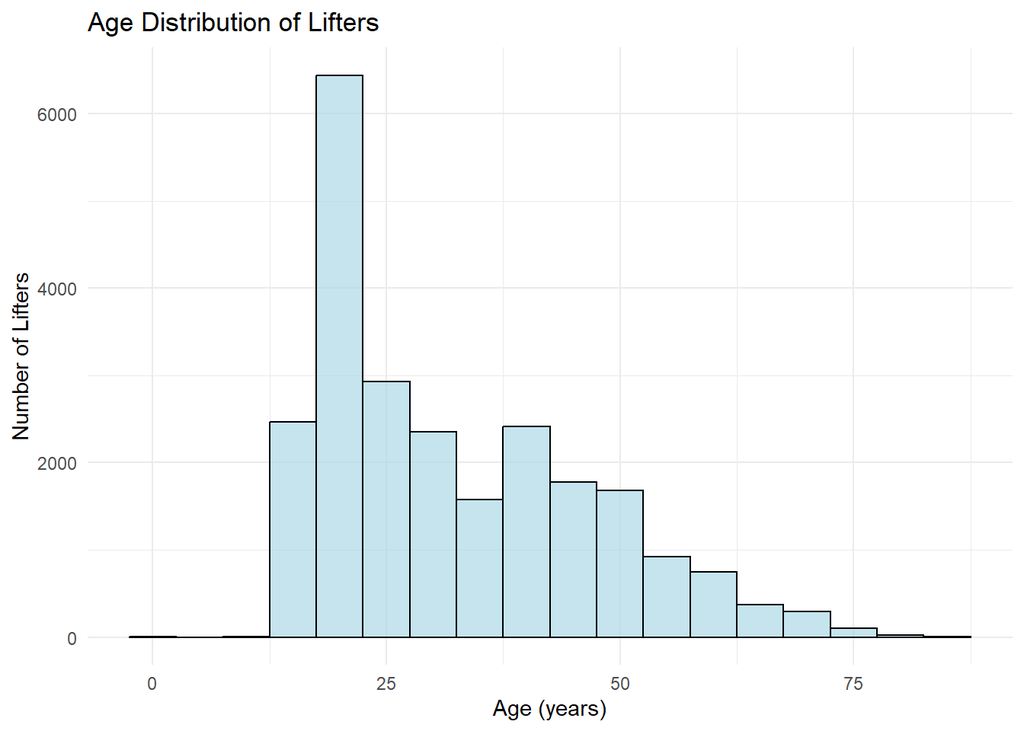

```r
# Histogram for Age Distribution
ggplot(cleaned_data, aes(x = age)) +
  geom_histogram(binwidth = 5, fill = "lightblue", color = "black", alpha = 0.7) +
  labs(title = "Age Distribution of Lifters", x = "Age (years)", y = "Number of Lifters") +
  theme_minimal()
```

**Observation**: The majority of lifters are aged 20 to 40, with fewer lifters beyond age 50. This indicates that powerlifting is predominantly a young adult sport, with most lifters in their physical prime.

#### 2. Impact of Equipment Type on Performance

Box plots were used to analyze how the use of different equipment (Single-ply, Raw, Wraps) impacts performance across squat, bench press, and deadlift lifts.

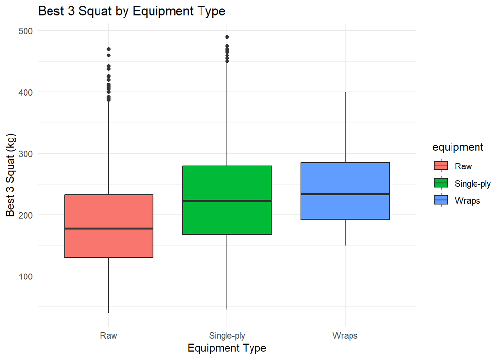

```r
# Box plot for Best 3 Squat by Equipment Type
ggplot(cleaned_data, aes(x = equipment, y = best3squat_kg, fill = equipment)) +
  geom_boxplot() +
  labs(title = "Best 3 Squat by Equipment Type", x = "Equipment Type", y = "Best 3 Squat (kg)") +
  theme_minimal()
```

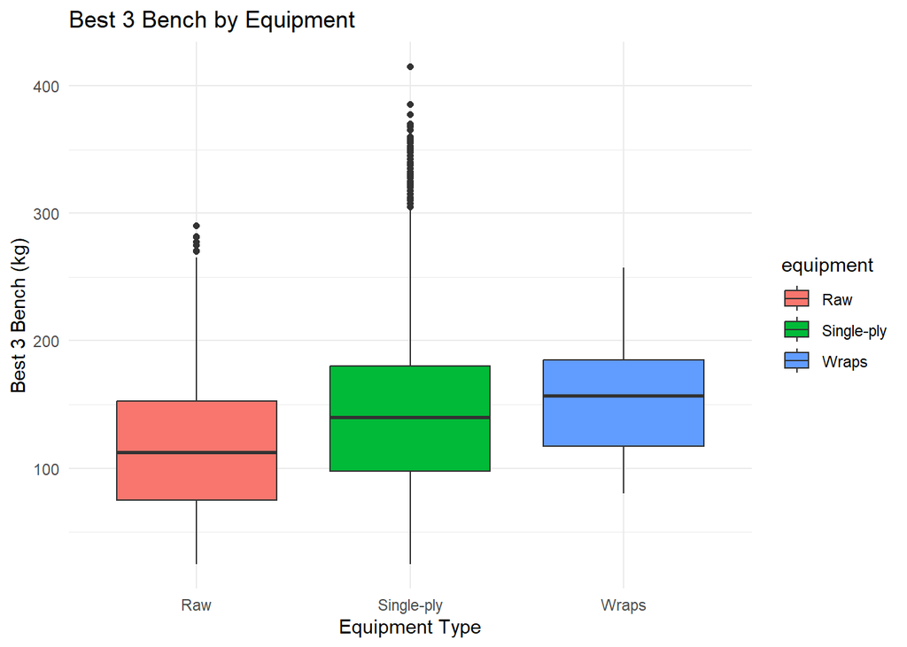

```r
# Box plot for Best 3 Bench by Equipment
ggplot(cleaned_data, aes(x = equipment, y = best3bench_kg, fill = equipment)) +
  geom_boxplot() +
  labs(title = "Best 3 Bench by Equipment", x = "Equipment Type", y = "Best 3 Bench (kg)") +
  theme_minimal()
```

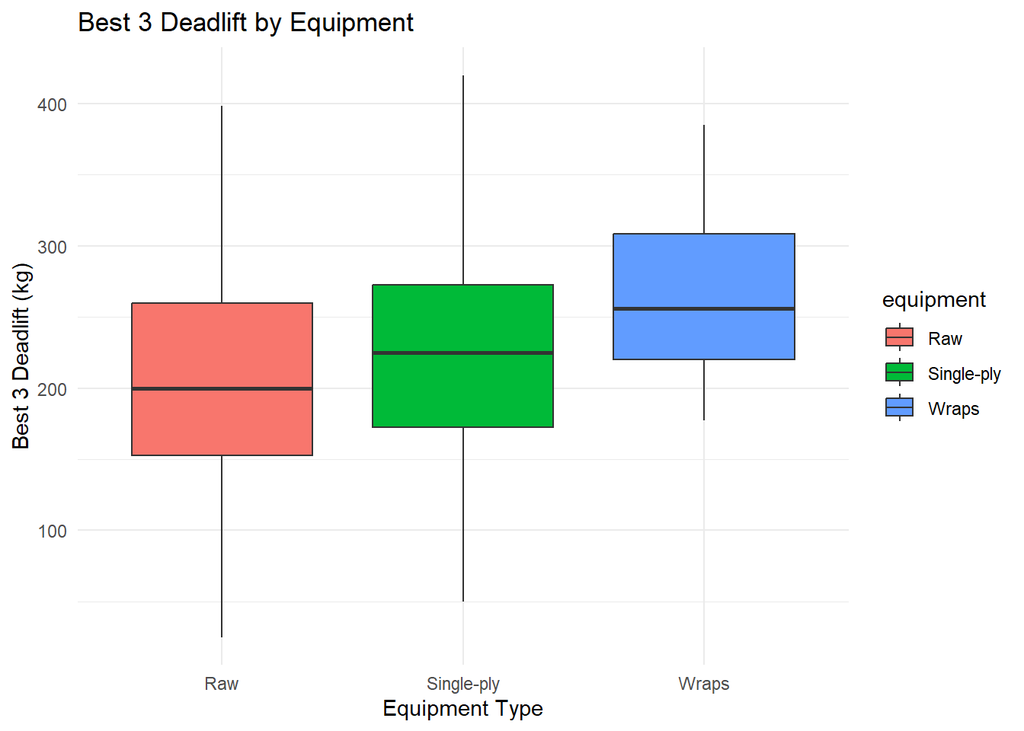

```r
# Box plot for Best 3 Deadlift by Equipment
ggplot(cleaned_data, aes(x = equipment, y = best3deadlift_kg, fill = equipment)) +
  geom_boxplot() +
  labs(title = "Best 3 Deadlift by Equipment", x = "Equipment Type", y = "Best 3 Deadlift (kg)") +
  theme_minimal()
```

#### 3. Age vs. Performance Analysis

To explore how age affects performance, scatter plots were created for each lift.

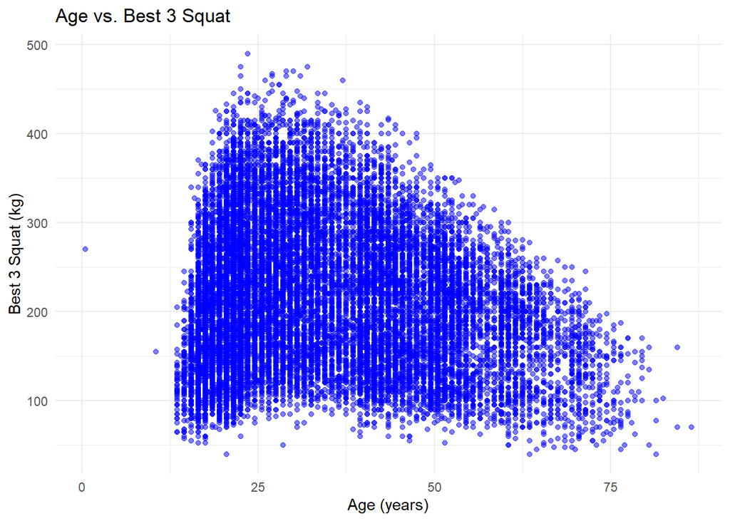

```r
# Scatter plot for Age vs. Best 3 Squat
ggplot(cleaned_data, aes(x = age, y = best3squat_kg)) +
  geom_point(alpha = 0.5, color = "blue") +
  labs(title = "Age vs. Best 3 Squat", x = "Age (years)", y = "Best 3 Squat (kg)") +
  theme_minimal()
```

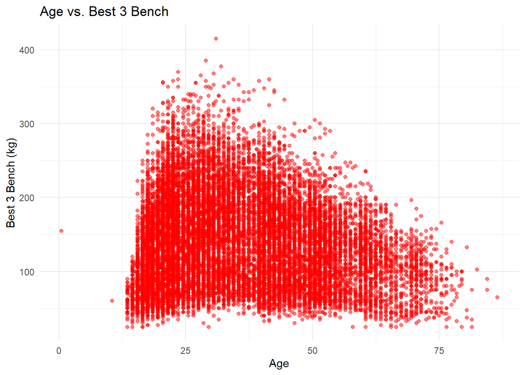

```r
# Scatter plot for Age vs. Best 3 Bench
ggplot(cleaned_data, aes(x = age, y = best3bench_kg)) +
  geom_point(alpha = 0.5, color = "red") +
  labs(title = "Age vs. Best 3 Bench", x = "Age", y = "Best 3 Bench (kg)") +
  theme_minimal()
```

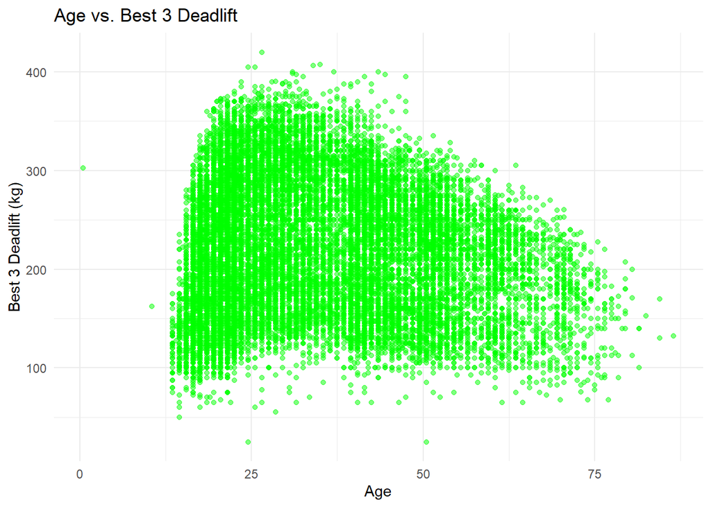

```r
# Scatter plot for Age vs. Best 3 Deadlift
ggplot(cleaned_data, aes(x = age, y = best3deadlift_kg)) +
  geom_point(alpha = 0.5, color = "green") +
  labs(title = "Age vs. Best 3 Deadlift", x = "Age", y = "Best 3 Deadlift (kg)") +
  theme_minimal()
```

**Observation**: There is a noticeable decline in performance for lifters beyond age 50, with the strongest performances generally observed between 20 to 40 years of age. This decline is natural due to the reduced muscle mass and recovery ability as lifters age.

#### 4. Weight Class Analysis

A box plot was created to visualize how weight classes impact squat performance, focusing on the spread of data for each class.

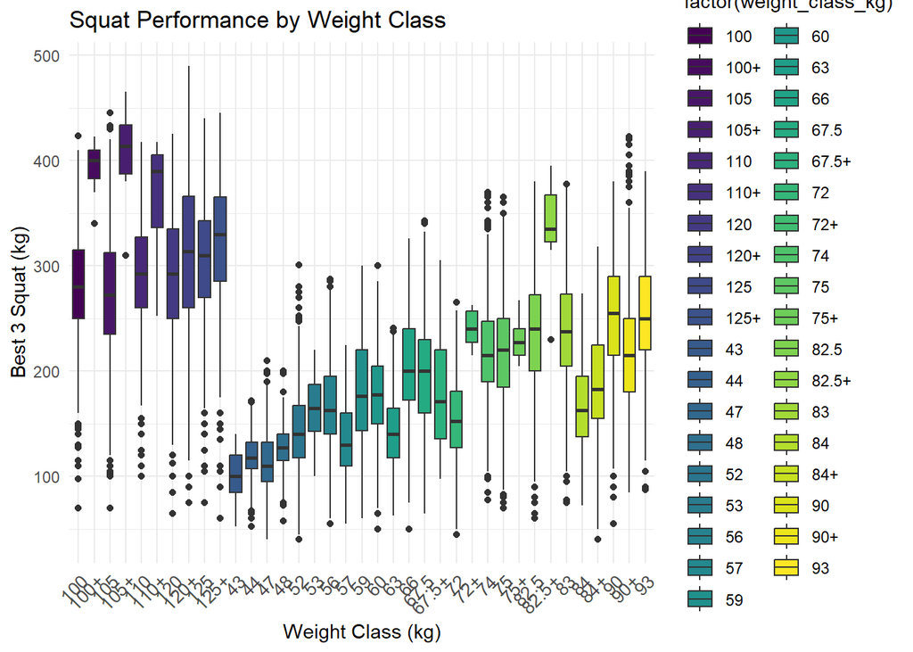

```r
# Box plot for Best 3 Squat by Weight Class
ggplot(cleaned_data, aes(x = factor(weight_class_kg), y = best3squat_kg)) +
  geom_boxplot(aes(fill = factor(weight_class_kg))) +
  scale_fill_viridis_d() +
  labs(title = "Squat Performance by Weight Class",
       x = "Weight Class (kg)",
       y = "Best 3 Squat (kg)") +
  theme_minimal() +
  theme(axis.text.x = element_text(angle = 45, hjust = 1, size = 10))
```

**Observation**: Heavier weight classes tend to lift more weight, but there is significant variation within classes, suggesting that other factors beyond bodyweight, such as training and technique, play a major role.

### Conclusion

The analysis reveals clear patterns in powerlifting performance, influenced by factors such as **age**, **weight class**, and **equipment type**. The insights gained are valuable for lifters looking to optimize their training regimen. Coaches can use these findings to tailor their approaches based on lifter demographics.

### Limitations and Future Work

- **Limitations**: The dataset contains missing values and possible data entry errors, which were mitigated but may still impact the results. There is also no information on other factors like **training regimen** or **injuries** that might influence performance.
- **Future Analysis**: Further analysis could focus on **trends over multiple competitions**.

### References

- **International Powerlifting Federation Dataset**
- **Tools and Libraries Used**: `ggplot2`, `dplyr`